# PEC 3 Machine Learning

Sheddad Kaid-Salah Ferrón

2024-01-02

# 1. SVM

**Escribir en el informe una sección con el título “Algoritmo Support Vector Machine” en el que se haga una breve explicación de su funcionamiento y sus características y además, se presente una tabla de sus fortaleza y debilidades.**

## Algoritmo Support Vector Machine (SVM)

Las Máquinas de Soporte Vectorial (SVM, por sus siglas en inglés) son un conjunto de métodos supervisados de aprendizaje automático utilizados principalmente para tareas de clasificación y regresión.

Estos algoritmos intentan dividir los datos de manera que haya un margen máximo entre las categorías y se distribuyan de manera uniforme. Su funcionamiento se centra en la determinación de hiperplanos dentro de un espacio de múltiples dimensiones, que se forma a partir de las diversas características de los datos.

El término *“Máquinas de Soporte Vectorial”* proviene del hecho de que las observaciones más cercanas al hiperplano de separación, pertenecientes a cada clase, son las que definen dicho hiperplano. Estas observaciones son conocidas como vectores de soporte.

Cuando los datos no son separables de forma lineal, se utilizan *kernels* (funciones de similitud) y un parámetro C, que hay que especificar a base de ensayo/error, para minimizar la función de coste.

Los kernels más populares son el lineal y el gausiano, con los que trabajaremos en esta práctica.

## Tabla de fortalezas y debilidades de SVM

| Fortalezas | Debilidades |
| --- | --- |
| Se puede utilizar para clasificación o problemas de predicción numérica | Encontrar el mejor modelo requiere pruebas de varias combinaciones de kernels y parámetros del modelo (prueba y error) |
| Funciona de forma óptima con ruido y no es muy propenso al sobreajuste (overfiting) | Puede ser lento para entrenar, especialmente a medida que aumenta el número de características |
| Puede ser más fácil de usar que neural redes, | Modelo difícil de interpretar de forma interna |

# 2. one-hot encoding

**Implementar una función para realizar una transformación one-hot encoding de las secuencias del fichero de datos *promoters.txt*. En caso de no lograr la implementación de dicha transformación, se puede utilizar el fichero promoters_onehot.txt con las secuencias codificados según una codificación one-hot para completar la actividad.**

Desarrollamos una función para hacer una transformación one-hot encoding para una secuencia.

```r
# Función para convertir un nucleótido a one-hot encoding
one_hot_encode_nucleotido <- function(nucleotido) {
    # Convertimos siempre a mayúsculas
    nucleotido.upper <- toupper(nucleotido)
    switch(nucleotido.upper, A = c(0, 0, 0, 1), C = c(0, 0, 1, 0), G = c(0, 1, 0,
        0), T = c(1, 0, 0, 0), rep(0, 4))  # Devuelve un vector de ceros si el nucleótido se reconoce
}

# Función para convertir toda una secuencia a one-hot encoding
one_hot_encode_seq <- function(seq) {
    # Separamos la secuencia
    split.seq <- strsplit(seq, "")[[1]]
    # Generamos la matriz one_hot con la secuencia
    matrix.seq <- sapply(split.seq, one_hot_encode_nucleotido)
    # Con todas las columnas de la matriz generamos un único vector one-hot
    vector.unico <- c(matrix.seq)
    # Devolvemos el vector con toda la secuencia one-hot
    vector.unico
}
```

# 3 Clasificador SVM

**Desarrollar un script en R que implemente un clasificador SVM.**

## a) Lectura de datos

**Leer los datos del fichero *promoters.txt*** .

Leemos los datos del fichero.

Nuestro fichero tiene 105 filas y 3 columnas.

Codificamos las secuencias que tenemos en nuestro fichero con la función one-hot desarrollada anteriormente.

```r
# Extraemos las dos primeras columnas 'class' y 'names'; las utilizaremos más
# adelante.
class_names_columnas <- promoters_df[, 1:2]

# Cogemos las secuencias de la 3a columna y las convertimos a one-hot
one_hot_encoded_sequences <- lapply(promoters_df[[3]], one_hot_encode_seq)
# Convertimos los resultados en una matriz de codificación one-hot
one_hot_encoded_matrix <- do.call(rbind, one_hot_encoded_sequences)

# Añadimos las columnas extraídas con la matriz de codificación one-hot
promoters_one.hot_df <- cbind(class_names_columnas, one_hot_encoded_matrix)
# Añadimos nombres a las dos primeras clumnas
names(promoters_one.hot_df)[1:2] <- c("class", "names")
# Convertimos la columna 'class' en factor
promoters_one.hot_df$class <- factor(promoters_one.hot_df$class)
```

## b) Separación de datos Training/Test

**Utilizando la semilla aleatoria 12345, separar los datos en dos partes, una parte para training (67%) y una parte para test (33%).**

Realizamos la separación de los datos de training (67%) y test (33%).

```r
# Separamos la base de datos en dos grupos: el grupo data.train con el 67 % de
# las observaciones (params$p.train) y el grupo data.test con el resto

# Fijamos la semilla para que los cálculos pseudo-aleatorios sean reproducibles
set.seed(params$seed)

# Obtenemos el número total de filas (datos) de parkinson
n <- nrow(promoters_one.hot_df)
# Calculamos el número de filas para entrenamiento y pruebas
n_train <- round(params$p.train * n)  # 67%
n_test <- n - n_train  # 33%
# Obtenemos los índices de filas al azar para entrenamiento
indices_train <- sample(1:n, n_train)
# Seleccionamos las filas para entrenamiento
data.train <- promoters_one.hot_df[indices_train, ]
# Eliminamos la segunda columna 'names'
data.train <- data.train[, -2]
# Seleccionamos las filas restantes para pruebas
data.test <- promoters_one.hot_df[-indices_train, ]
# Eliminamos la segunda columna 'names'
data.test <- data.test[, -2]
```

## c) Modelos SVM

**Utilizar el kernel lineal y el kernel RBF para crear sendos modelos SVM basados en el training para predecir las clases en los datos del test.**

### kernel lineal

Relalizamos el modelo predictivo con el kernel lineal.

```r
require(kernlab)
# Hacemos el clasificador de promotores con el modelo lineal ksvm.
mod_ksvm_lineal <- ksvm(class ~ ., data = data.train, kernel = "vanilladot")
# Vemos la información del modelo
mod_ksvm_lineal
```

```
Support Vector Machine object of class "ksvm"

SV type: C-svc  (classification)
 parameter : cost C = 1

Linear (vanilla) kernel function.

Number of Support Vectors : 52

Objective Function Value : -0.0835
Training error : 0
```

Hacemos la predicción de los datos del test con el kernel lineal

```r
# Predicción del test con el kernel lineal
pred_ksvm_lineal <- predict(mod_ksvm_lineal, data.test)

# Métricas de rendimiento
require(caret)
# Matriz de confusión
res <- table(pred_ksvm_lineal, data.test$class)
conf.mat.ksvm.lineal <- confusionMatrix(res, positive = "+")
# Visualizamos
conf.mat.ksvm.lineal
```

```
Confusion Matrix and Statistics


pred_ksvm_lineal  -  +
               - 17  2
               +  3 13

               Accuracy : 0.8571
                 95% CI : (0.6974, 0.9519)
    No Information Rate : 0.5714
    P-Value [Acc > NIR] : 0.0003014

                  Kappa : 0.7107

 Mcnemar's Test P-Value : 1.0000000

            Sensitivity : 0.8667
            Specificity : 0.8500
         Pos Pred Value : 0.8125
         Neg Pred Value : 0.8947
             Prevalence : 0.4286
         Detection Rate : 0.3714
   Detection Prevalence : 0.4571
      Balanced Accuracy : 0.8583

       'Positive' Class : +
```

### kernel RBF

Relalizamos el modelo predictivo con el kernel RBF

```r
# require(kernlab) Hacemos el clasificador de promotores con el modelo lineal
# ksvm.
mod_ksvm_RBF <- ksvm(class ~ ., data = data.train, kernel = "rbfdot")
# Vemos la información del modelo
mod_ksvm_RBF
```

```
Support Vector Machine object of class "ksvm"

SV type: C-svc  (classification)
 parameter : cost C = 1

Gaussian Radial Basis kernel function.
 Hyperparameter : sigma =  0.0021798065194073

Number of Support Vectors : 66

Objective Function Value : -30.1756
Training error : 0
```

Hacemos la predicción de los datos del test con el kernel RBF

```r
# Predicción del test con el kernel RBF
pred_ksvm_RBF <- predict(mod_ksvm_RBF, data.test)

# Métricas de rendimiento require(caret) Matriz de confusión
res <- table(pred_ksvm_RBF, data.test$class)
conf.mat.ksvm.RBF <- confusionMatrix(res, positive = "+")
# Visualizamos
conf.mat.ksvm.RBF
```

```
Confusion Matrix and Statistics


pred_ksvm_RBF  -  +
            - 16  1
            +  4 14

               Accuracy : 0.8571
                 95% CI : (0.6974, 0.9519)
    No Information Rate : 0.5714
    P-Value [Acc > NIR] : 0.0003014

                  Kappa : 0.7154

 Mcnemar's Test P-Value : 0.3710934

            Sensitivity : 0.9333
            Specificity : 0.8000
         Pos Pred Value : 0.7778
         Neg Pred Value : 0.9412
             Prevalence : 0.4286
         Detection Rate : 0.4000
   Detection Prevalence : 0.5143
      Balanced Accuracy : 0.8667

       'Positive' Class : +
```

## d) SVM con caret

**Usar el paquete caret con el modelo svmLinear para implementar un SVM con kernel lineal y 3-fold crossvalidation.**

Con la función `createDataPartition` del paquete `caret` creamos la partición de los datos de train( 67%) y test (33%).  
Utilizaremos ambos sets, el que hemos creado nosotros anteriormente y este, para realizar los modelos con los dos sets con el fin de comparar los resultados.

```r
# library(caret) Partición de datos
set.seed(params$seed)
# Seleccionamos el % con p.train de los parámetros (2/3)
indices_train.caret <- createDataPartition(y = promoters_one.hot_df$class, p = params$p.train,
    list = FALSE)
# Creamos los dos sets
data.train.caret <- promoters_one.hot_df[indices_train.caret, ]
# Eliminamos la segunda columna 'names'
data.train.caret <- data.train.caret[, -2]
# Seleccionamos las filas restantes para pruebas
data.test.caret <- promoters_one.hot_df[-indices_train.caret, ]
# Eliminamos la segunda columna 'names'
data.test.caret <- data.test.caret[, -2]

# Para comprobar si la partición es válida. Debe dar sobre 2 en el caso de 2/3
nrow(data.train.caret)/nrow(data.test.caret)
```

```
[1] 2.088235
```

### svmLinear

Creamos el modelo SVM lineal con los datos de entrenamiento del paquete `caret`.

```r
# Hacemos el clasificador de promotores con el modelo lineal ksvm del paquete
# 'caret'.  Train sin repetición tune_grid <- NULL
tune_grid <- expand.grid(C = 1)
mod_svmLinear.caret <- train(class ~ ., data.train.caret, method = "svmLinear", trControl = trainControl(method = "none"),
    tuneGrid = tune_grid, trace = FALSE)
# Vemos la información del modelo
mod_svmLinear.caret
```

```
Support Vector Machines with Linear Kernel

 71 samples
228 predictors
  2 classes: '-', '+'

No pre-processing
Resampling: None
```

Hacemos la predicción de los datos del test con el modelo SVM con kernel lineal y los datos de test del paquete `caret`.

```r
# Predicción del test con kernel lineal del paquete `caret`
pred_svmLinear.caret <- predict(mod_svmLinear.caret, data.test.caret)

# Métricas de rendimiento require(caret) Matriz de confusión
res <- table(pred_svmLinear.caret, data.test.caret$class)
conf.mat.svmLinear.caret <- confusionMatrix(res, positive = "+")
# Visualizamos
conf.mat.svmLinear.caret
```

```
Confusion Matrix and Statistics


pred_svmLinear.caret  -  +
                   - 17  2
                   +  0 15

               Accuracy : 0.9412
                 95% CI : (0.8032, 0.9928)
    No Information Rate : 0.5
    P-Value [Acc > NIR] : 3.469e-08

                  Kappa : 0.8824

 Mcnemar's Test P-Value : 0.4795

            Sensitivity : 0.8824
            Specificity : 1.0000
         Pos Pred Value : 1.0000
         Neg Pred Value : 0.8947
             Prevalence : 0.5000
         Detection Rate : 0.4412
   Detection Prevalence : 0.4412
      Balanced Accuracy : 0.9412

       'Positive' Class : +
```

Ahora entrenamos el modelo utilizando los datos que hemos utilizado en la función `ksvm`.

```r
# Hacemos el clasificador de promotores con el modelo lineal ksvm del paquete
# 'caret'.  Train sin repetición tunegrid <- NULL
tune_grid <- expand.grid(C = 1)
mod_svmLinear <- train(class ~ ., data.train, method = "svmLinear", trControl = trainControl(method = "none"),
    tuneGrid = tune_grid, trace = FALSE)
# Vemos la información del modelo
mod_svmLinear
```

```
Support Vector Machines with Linear Kernel

 70 samples
228 predictors
  2 classes: '-', '+'

No pre-processing
Resampling: None
```

Hacemos la predicción de los datos del test con el modelo SVM con kernel lineal del paquete `caret`.

```r
# Predicción del test con kernel lineal del paquete `caret`
pred_svmLinear <- predict(mod_svmLinear, data.test)

# Métricas de rendimiento require(caret) Matriz de confusión
res <- table(pred_svmLinear, data.test$class)
conf.mat.svmLinear <- confusionMatrix(res, positive = "+")
# Visualizamos
conf.mat.svmLinear
```

```
Confusion Matrix and Statistics


pred_svmLinear  -  +
             - 17  2
             +  3 13

               Accuracy : 0.8571
                 95% CI : (0.6974, 0.9519)
    No Information Rate : 0.5714
    P-Value [Acc > NIR] : 0.0003014

                  Kappa : 0.7107

 Mcnemar's Test P-Value : 1.0000000

            Sensitivity : 0.8667
            Specificity : 0.8500
         Pos Pred Value : 0.8125
         Neg Pred Value : 0.8947
             Prevalence : 0.4286
         Detection Rate : 0.3714
   Detection Prevalence : 0.4571
      Balanced Accuracy : 0.8583

       'Positive' Class : +
```

### 3-fold crossvalidation

Creamos el modelo 3-fold crossvalidation con los datos de entrenamiento del paquete `caret`.

```r
# Hacemos el clasificador de promotores con 3-fold crossvalidation del paquete
# 'caret'.  tune_grid <- NULL
tune_grid <- expand.grid(C = 1.5)
mod_3fold_cross.caret <- train(class ~ ., data.train.caret, method = "svmLinear",
    trControl = trainControl(method = "cv", number = 3), tuneGrid = tune_grid, trace = FALSE)
# Vemos la información del modelo
mod_3fold_cross.caret
```

```
Support Vector Machines with Linear Kernel

 71 samples
228 predictors
  2 classes: '-', '+'

No pre-processing
Resampling: Cross-Validated (3 fold)
Summary of sample sizes: 48, 47, 47
Resampling results:

  Accuracy   Kappa
  0.8182367  0.6363636

Tuning parameter 'C' was held constant at a value of 1.5
```

Hacemos la predicción de los datos del test con el modelo SVM con kernel lineal del paquete `caret`.

```r
# Predicción del test con 3-fold crossvalidation
pred_3fold_cross.caret <- predict(mod_3fold_cross.caret, data.test.caret)

# Métricas de rendimiento require(caret) Matriz de confusión
res <- table(pred_3fold_cross.caret, data.test.caret$class)
conf.mat.3fold.cross.caret <- confusionMatrix(res, positive = "+")
# Visualizamos
conf.mat.3fold.cross.caret
```

```
Confusion Matrix and Statistics


pred_3fold_cross.caret  -  +
                     - 17  2
                     +  0 15

               Accuracy : 0.9412
                 95% CI : (0.8032, 0.9928)
    No Information Rate : 0.5
    P-Value [Acc > NIR] : 3.469e-08

                  Kappa : 0.8824

 Mcnemar's Test P-Value : 0.4795

            Sensitivity : 0.8824
            Specificity : 1.0000
         Pos Pred Value : 1.0000
         Neg Pred Value : 0.8947
             Prevalence : 0.5000
         Detection Rate : 0.4412
   Detection Prevalence : 0.4412
      Balanced Accuracy : 0.9412

       'Positive' Class : +
```

Ahora entrenamos el modelo utilizando los datos que hemos utilizado en la función `ksvm`.

```r
# Hacemos el clasificador de promotores con 3-fold crossvalidation del paquete
# 'caret'.  tune_grid <- NULL
tune_grid <- expand.grid(C = 1.5)
mod_3fold_cross <- train(class ~ ., data.train, method = "svmLinear", trControl = trainControl(method = "cv",
    number = 3), tuneGrid = tune_grid, trace = FALSE)
# Vemos la información del modelo
mod_3fold_cross
```

```
Support Vector Machines with Linear Kernel

 70 samples
228 predictors
  2 classes: '-', '+'

No pre-processing
Resampling: Cross-Validated (3 fold)
Summary of sample sizes: 47, 46, 47
Resampling results:

  Accuracy   Kappa
  0.9293478  0.8574121

Tuning parameter 'C' was held constant at a value of 1.5
```

Hacemos la predicción de los datos del test con el modelo SVM con kernel lineal del paquete `caret`.

```r
# Predicción del test con 3-fold crossvalidation
pred_3fold_cross <- predict(mod_3fold_cross, data.test)

# Métricas de rendimiento require(caret) Matriz de confusión
res <- table(pred_3fold_cross, data.test$class)
conf.mat.3fold.cross <- confusionMatrix(res, positive = "+")
# Visualizamos
conf.mat.3fold.cross
```

```
Confusion Matrix and Statistics


pred_3fold_cross  -  +
               - 17  2
               +  3 13

               Accuracy : 0.8571
                 95% CI : (0.6974, 0.9519)
    No Information Rate : 0.5714
    P-Value [Acc > NIR] : 0.0003014

                  Kappa : 0.7107

 Mcnemar's Test P-Value : 1.0000000

            Sensitivity : 0.8667
            Specificity : 0.8500
         Pos Pred Value : 0.8125
         Neg Pred Value : 0.8947
             Prevalence : 0.4286
         Detection Rate : 0.3714
   Detection Prevalence : 0.4571
      Balanced Accuracy : 0.8583

       'Positive' Class : +
```

### Resultados

Los modelos entrenados con los datos que hemos separado para `ksvm` dan exáctamente los mismos resultados. Lo apropiado es escoger el modelo más simple.

Al utilizar los datos separados con la función `createDataPartition`, también observamos que tanto el modelo *SVM lineal* como *3-fold crossvalidation* nos dan los mismos resultados. Estos modelos dan mejores resultados (accuracy, kappa) que los anteriores.

## e) Evaluación kernel RBF

**Evaluar el rendimiento del algoritmo SVM con kernel RBF para diferentes valores de los hiperparámetros C y sigma. Orientativamente, se propone explorar valores de sigma en el intervalo (0.005,0.5) y valores de C en el intervalo (0.1, 2). Una manera fácil de hacerlo es utilizar el paquete caret con el modelo svmRadial. Mostrar un gráfico del rendimiento según los valores de los hiperparámetros explorados. Comentar los resultados.**

```r
# Configuramos el control de entrenamiento para la validación cruzada
train_control <- trainControl(method = "cv", number = 5, repeats = 0)

# Definimos los hiperparámetros C y sigma en los intervalos planteados.
grid <- expand.grid(sigma = seq(0.005, 0.5, length = 5), C = seq(0.1, 2, length = 5))

# Entrenamos los modelos SVM con kernel RBF con el paquete caret
svm_model <- train(class ~ ., data = data.train, method = "svmRadial", trControl = train_control,
    tuneGrid = grid)

# Obtenemos los resultados del conjunto de modelos
resultados <- svm_model$results

# Ordenamos los resultados por 'Accuracy'
resultados_ordenados <- resultados[order(-resultados$Accuracy), ]

# Creamos una tabla resumen
tabla_resumen <- resultados_ordenados[, c("sigma", "C", "Accuracy", "Kappa")]
tabla_resumen
```

```
     sigma     C  Accuracy     Kappa
3  0.00500 1.050 0.9263736 0.8496553
4  0.00500 1.525 0.9263736 0.8496553
5  0.00500 2.000 0.9263736 0.8496553
2  0.00500 0.575 0.5991209 0.1401253
1  0.00500 0.100 0.5429304 0.0000000
6  0.12875 0.100 0.5429304 0.0000000
7  0.12875 0.575 0.5429304 0.0000000
8  0.12875 1.050 0.5429304 0.0000000
9  0.12875 1.525 0.5429304 0.0000000
10 0.12875 2.000 0.5429304 0.0000000
11 0.25250 0.100 0.5429304 0.0000000
12 0.25250 0.575 0.5429304 0.0000000
13 0.25250 1.050 0.5429304 0.0000000
14 0.25250 1.525 0.5429304 0.0000000
15 0.25250 2.000 0.5429304 0.0000000
16 0.37625 0.100 0.5429304 0.0000000
17 0.37625 0.575 0.5429304 0.0000000
18 0.37625 1.050 0.5429304 0.0000000
 [ reached 'max' / getOption("max.print") -- omitted 7 rows ]
```

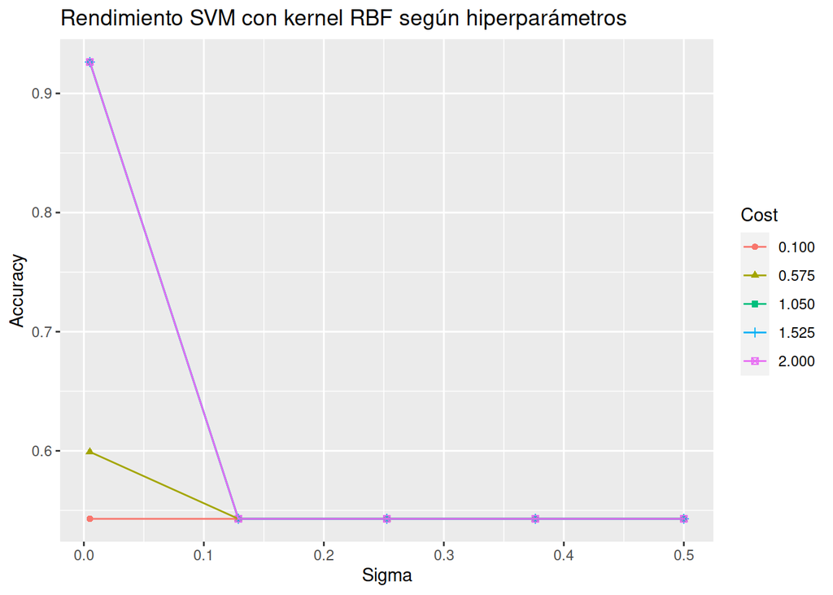

```r
# Mostramos un gráfico del rendimiento según los valores Cargamos la librería
# ggplot2
require(ggplot2)

# 2. Creamos el histograma con ggplot2
pl <- ggplot(data = svm_model)
pl2 <- pl + labs(title = "Rendimiento SVM con kernel RBF según hiperparámetros",
    x = "Sigma", y = "Accuracy")
pl2
```

## f) Tabla resumen

**Crear una tabla resumen de los diferentes modelos y sus rendimientos. Comentar y comparar los resultados de la clasificación en función de los valores generales de la clasificación como accuracy y otros para los diferentes clasificadores obtenidos. ¿Qué modelo resulta ser el mejor?**

[output not shown]

# Referencias

Harley, C., and R. Reynolds. 1987. “Analysis of e. Coli Promoter Sequences.” *Nucleic Acids Research* 15: 2343–61. https://doi.org/ 10.1093/nar/15.5.2343 .

Lantz, Brett. 2015. *Machine Learning with r*. Packt Publishing Ltd. http://www.packtpub.com/books/content/machine-learning-r.